# price_surface_location

import the raw data from csv file and verify the data type of each column

```r
library(MASS)
library(ISLR)
setwd("/Users/lulu/BIGDATA/seloger_mining/data-csv/samples")
dat_ori=read.csv("details.csv",header = TRUE)
#dat_ori=dat_ori[idAnnonce!="idAnnonce",]
#attach(dat_ori)
#linear regression prix~surface+nbPieces+cp+siLotNeuf+consoEnergie+bilanCOnsoEnergie
str(dat_ori)
```

```
## 'data.frame':    32120 obs. of  14 variables:
##  $ sampleDate       : int  NA NA NA NA NA NA NA NA NA NA ...
##  $ idAnnonce        : int  93235705 97099413 92964725 93800443 98967581 98052249 97651527 85837597 98359343 85220679 ...
##  $ dtFraicheur      : Factor w/ 9341 levels "2015-04-25T11:33:09",..: 603 625 460 566 428 127 528 401 599 586 ...
##  $ prix             : num  135000 135000 119500 123000 135000 ...
##  $ surface          : num  83 65 73 43.9 40 65 48 52 65 60.2 ...
##  $ nbPieces         : int  4 4 3 2 2 3 2 2 3 3 ...
##  $ cp               : int  73000 73000 69009 69270 73000 69100 69100 73000 73000 73000 ...
##  $ ville            : Factor w/ 249 levels "33","34","75",..: 32 33 103 65 32 246 246 32 13 32 ...
##  $ latitude         : num  45.6 45.6 45.8 45.8 45.6 ...
##  $ longitude        : num  5.92 5.92 4.84 4.85 5.92 ...
##  $ permaLien        : Factor w/ 9130 levels "http://www.seloger.com/annonces/achat-de-prestige/appartement/annecy-74/100866667.htm?p=",..: 1373 1402 2605 1807 1436 8107 8130 1349 957 1348 ...
##  $ siLotNeuf        : Factor w/ 2 levels "false","true": 1 1 1 1 1 1 1 1 1 1 ...
##  $ consoEnergie     : int  108 345 200 191 180 293 276 195 313 305 ...
##  $ bilanConsoEnergie: Factor w/ 7 levels "A","B","C","D",..: 3 6 4 4 4 5 5 4 5 5 ...
```

```r
dat_ori$idAnnonce=as.factor(dat_ori$idAnnonce)
dat_ori$cp=as.factor(dat_ori$cp)
```

*plot data and remove outliers and duplicates* surface>=400 is regarded as outlier *to remove duplicates: sort by column dtFraicheur in decreasing order and then apply the function duplicated on idAnnonce

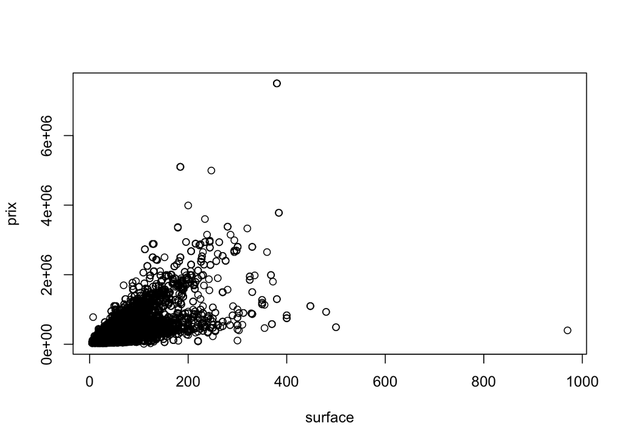

```r
plot(prix~surface,log= "",data=dat_ori)
```

```r
#boxplot(prix~nbPieces,data=dat_ori)
#boxplot(prix~bilanConsoEnergie,data=dat_ori)

dat_ori.surfaceOutlier=dat_ori[dat_ori$surface>=400,]
dat_ori.surfaceSubset=dat_ori[dat_ori$surface<400,]

dat_ori.surfaceSubset$dtFraicheur=strptime(dat_ori.surfaceSubset$dtFraicheur, "%Y-%m-%dT%H:%M:%S",tz="Europe/Paris")
index_dec=order(dat_ori.surfaceSubset$dtFraicheur,decreasing=TRUE)
dat_ori.surfaceSubset=dat_ori.surfaceSubset[index_dec,]
length(dat_ori.surfaceSubset$idAnnonce) # 9064
```

```
## [1] 32103
```

```r
dat.uniq=dat_ori.surfaceSubset[!duplicated(dat_ori.surfaceSubset$idAnnonce),]#9058 rows?
```

look at two major predictors: surface, location when ploting prix with the variable surface, we see there are more than one patterns, which is probably due to locations, we need to segregate the data by cp. There are 159 different “code postale” and 9058 samples. first of all, we put cp with less or equal than 50 samples in a group called dat.minor and the rest in another super group dat.major, the plot show there are still more than one pattern in dat.major.

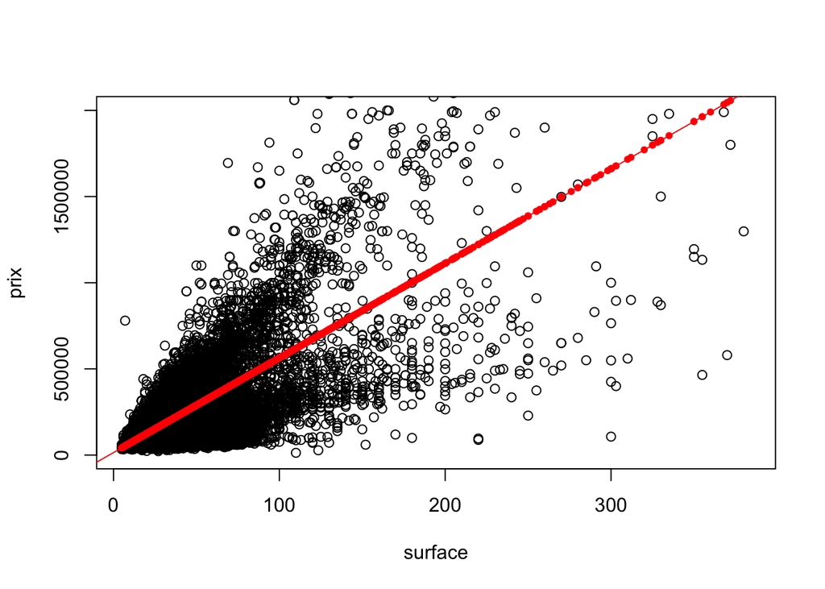

```r
plot(prix~surface,data=dat.uniq,ylim=c(0,2000000))
fit1=lm(prix~surface,data=dat.uniq)
points(dat.uniq$surface,fitted(fit1),col="red",pch=20)
abline(fit1,col="red")
```

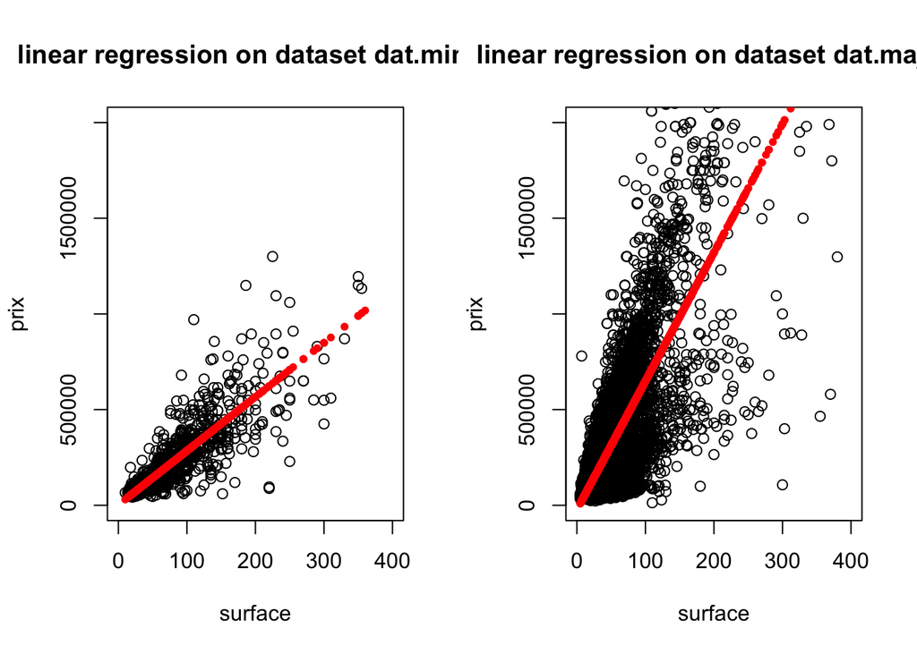

```r
# to refine the data collect by location
rank=sort(table(dat.uniq$cp))
#ileFrance=c("75","77","78","91","92","93","94","95")
dat.minor=dat.uniq[dat.uniq$cp %in% names(rank[rank<=50]),]
dat.major=dat.uniq[dat.uniq$cp %in% names(rank[rank>50]),]
# a function given a dataset, calculate the coifficient of surface using simple linear regression
plotwithreg<-function(dataset,name){
  plot(prix~surface,data=dataset,xlim=c(0,400),ylim=c(0,2000000),main=paste("linear regression on dataset",name))
  fit1=lm(prix~surface,data=dataset)
  points(dataset$surface,fitted(fit1),col="red",pch=20)
  return(fit1)
}
par(mfrow=c(1,2))
fit.minor=plotwithreg(dataset = dat.minor,name="dat.minor")
fit.major=plotwithreg(dataset = dat.major,name="dat.major")
```

Next,we will separate the dataset into subset by the column cp. linearity is visualized in each section, we could see similarity among certains cities

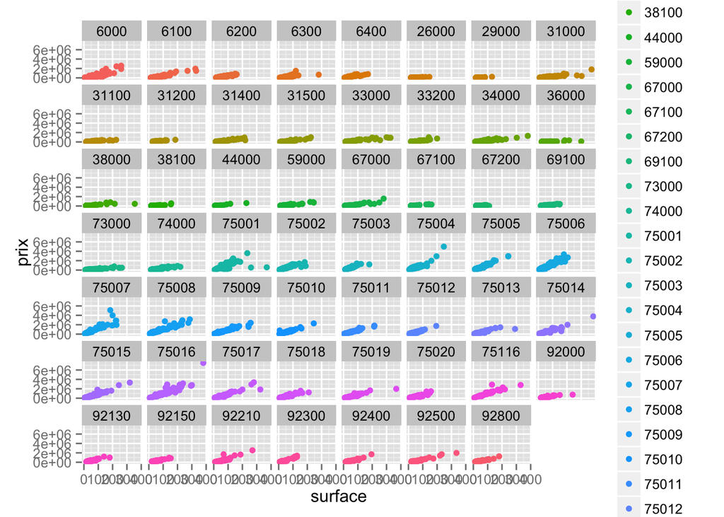

```r
library(ggplot2)
ggplot(dat.major)+geom_point(aes(x=surface,y=prix,colour=cp))+facet_wrap(~cp)
```

apply simple linear regression to each subset according to cp we see the coefficient of surface which represent the rise of price per square meter.

```r
rank.major=names(rank[rank>50])
score <- data.frame(cp=character(),intercept=numeric(),
                 surface=numeric(),
                 stringsAsFactors=FALSE)
for (i in 1:length(rank.major))
{
  subset=dat.major[dat.major$cp==rank.major[i],]
  fit=lm(prix~surface,data=subset)
  score[i,]=c(rank.major[i],coef(fit))
}

score$surface=as.numeric(score$surface)
score[order(score$surface,decreasing = TRUE),]
```

```
##       cp         intercept    surface
## 43 75007 -31569.5883744863 13461.9033
## 38 75004 -83567.1596239392 13281.5166
## 48 75006 -15914.0437640804 13269.8972
## 51 75005 -39200.7450616142 11965.9590
## 35 75016 -110845.950171481 11603.2931
## 34 75008  32148.1831836195  9984.5025
## 54 75015 -8298.87324902301  9384.1322
## 1  75116  88690.4312294728  9371.8326
## 29 75003  43724.0374430428  9353.4161
## 21 75017 -4515.32058890847  9174.1986
## 50 75014  -8927.3884878181  9076.6796
## 12 92300 -33658.6948939731  8976.1116
## 46 75009  27881.2004779173  8549.6616
## 40 75010  2415.87048416534  8480.3687
```

[output cut: 41 more lines]

Next we add another predictor:nbPieces to recalculate. The result is less interpreble.

```r
score2 <- data.frame(cp=character(),intercept=numeric(),
                 surface=numeric(),
                 nbPieces=numeric(),
                 surface_nbPieces=numeric(),
                 stringsAsFactors=FALSE)
for (i in 1:length(rank.major))
{
  subset=dat.major[dat.major$cp==rank.major[i],]
  fit=lm(prix~surface*nbPieces,data=subset)
  score2[i,]=c(rank.major[i],coef(fit))
}

score2$surface=as.numeric(score2$surface)
score2[order(score2$surface,decreasing = TRUE),]
```

```
##       cp         intercept    surface          nbPieces  surface_nbPieces
## 45 75001 -167633.454611811 20296.3975 -29299.4918090903 -1481.53166362049
## 43 75007 -65666.7414798553 19974.5554 -84631.6642682717 -641.427704710123
## 35 75016  116583.776792442 17431.4564 -222070.927022246 -39.4124421809506
## 1  75116 -77124.7268015149 14666.3323  -10696.632283273  -683.74342678997
## 34 75008  15640.7404702355 13957.0070 -61513.2123198654 -341.468742539766
## 6   6300   18080.320962707 12841.2241 -170797.136845228 -437.012642748772
## 21 75017 -24942.2686888136 12660.9419 -42457.8540781715 -299.323577769439
## 48 75006  51863.8851569923 11809.8065 -25120.4040301355  368.858694048758
## 29 75003 -45537.1063873998 10120.8571   55923.394538424 -535.900839524472
## 46 75009 -4436.14205027451 10075.2078 -1569.58192958397 -222.729027025745
## 54 75015   41922.173584874  9277.6889 -34343.6544782866   212.66746123595
## 37 75011 -4740.03398354747  7964.8923  16387.3278759616 -27.6352407499737
## 50 75014  43958.5847591829  7446.1760 -15196.1807284812  326.276947806875
## 40 75010  47054.1423136775  7424.3414 -22469.8344886842  354.554326339961
```

[output cut: 41 more lines]